# CourseraMachineLearningFinalProject

Irina Ualiyeva

2022-05-25

# Practical Machine Learning Course - Final Project

## Data

The training data for this project are available here: https://d396qusza40orc.cloudfront.net/predmachlearn/pml-training.csv. The test data are available here: https://d396qusza40orc.cloudfront.net/predmachlearn/pml-testing.csv. The data for this project come from this source: http://groupware.les.inf.puc-rio.br/har.

## Loading libraries

```r
library(caret)
```

```r
library(readr)
library(lattice)
library(ggplot2)
library(corrplot)
```

## Loading Data

```r
pml_training <- read_csv("datasets/pml-training.csv")
```

```
## * `` -> ...1
```

```r
pml_testing <- read_csv("datasets/pml-testing.csv")
```

```
## * `` -> ...1
```

## Data Preprocessing

```r
dim(pml_training)
```

```
## [1] 19622   160
```

```r
dim(pml_testing)
```

```
## [1]  20 160
```

We see that there are 160 variables and 19622 observations in the training set, while 20 for the test set. Next step is to remove predictors with nearly zero variance, NAN, predictors that do not intuitive sense for prediction and correlated with each other.

```r
#Removing near zero variance variables
nzv <- nearZeroVar(pml_training)
training <- pml_training[, -nzv]
```

```r
#Removing NA variables
training <- training[, colSums(is.na(training))==0]

#Removing first six features
training <- training[, -(1:6)]

dim(training)
```

```
## [1] 19622    53
```

```r
x <- training[,-53]

M <- abs(cor(x))
diag(M) <- 0
which(M > 0.8,arr.ind=T)
```

```
##                  row col
## yaw_belt           3   1
## total_accel_belt   4   1
## accel_belt_y       9   1
## accel_belt_z      10   1
## accel_belt_x       8   2
## magnet_belt_x     11   2
## roll_belt          1   3
## roll_belt          1   4
## accel_belt_y       9   4
## accel_belt_z      10   4
## pitch_belt         2   8
## magnet_belt_x     11   8
## roll_belt          1   9
## total_accel_belt   4   9
## accel_belt_z      10   9
## roll_belt          1  10
## total_accel_belt   4  10
## accel_belt_y       9  10
## pitch_belt         2  11
## accel_belt_x       8  11
## gyros_arm_y       19  18
## gyros_arm_x       18  19
## magnet_arm_x      24  21
## accel_arm_x       21  24
## magnet_arm_z      26  25
## magnet_arm_y      25  26
## accel_dumbbell_x  34  28
## accel_dumbbell_z  36  29
## gyros_dumbbell_z  33  31
## gyros_forearm_z   46  31
## gyros_dumbbell_x  31  33
## gyros_forearm_z   46  33
## pitch_dumbbell    28  34
## yaw_dumbbell      29  36
## gyros_forearm_z   46  45
## gyros_dumbbell_x  31  46
## gyros_dumbbell_z  33  46
## gyros_forearm_y   45  46
```

```r
highlyCorDescr <- findCorrelation(M, cutoff = 0.8)
x <- x[,-highlyCorDescr]
```

Now we form new training dataset with 39 predictors and 19622 records, and define targeted variable “classe” as factor variable, other predictors as dataframe.

```r
dim(x)
```

```
## [1] 19622    39
```

```r
Y <- training$classe
Y <- as.matrix(Y)
trainframe <- data.frame(x, as.factor(Y))
```

## Modeling

### Splitting training data

Split the training data into training and testing data.

```r
set.seed(32323)

inTrain <- createDataPartition(y=trainframe$as.factor.Y., p=0.75, list=F)
train <- trainframe[inTrain, ]
test <- trainframe[-inTrain, ]

dim(train)
```

```
## [1] 14718    40
```

```r
dim(test)
```

```
## [1] 4904   40
```

### Modeling

We train three baseline machine learning algorithms: Gradient Boosted Trees, Random Forest and Decision Trees. Instruct train to use 4-fold CV to select optimal tuning parameters (see Appendix), also 4-fold CV shows the best result in the scientific article (Ugulino et al. 2012).

```r
fitControl <- trainControl(method="cv", number=4, verboseIter=F)
```

#### Decision Trees

```r
set.seed(123)

# Build Decision Trees Model
rpart_model <- caret::train(as.factor.Y. ~., train, method="rpart", trControl = fitControl)

# Predict Decision Trees Model on the validation data
rpart_predict <- predict(rpart_model, test)

#Accuracy
confusionMatrix(rpart_predict, factor(test$as.factor.Y.))
```

```
## Confusion Matrix and Statistics
##
##           Reference
## Prediction    A    B    C    D    E
##          A 1274  423  390  301  209
##          B   25  314   27  148  170
##          C   76  178  337   84  195
##          D   20   33  101  215   36
##          E    0    1    0   56  291
##
## Overall Statistics
##
##                Accuracy : 0.4957
##                  95% CI : (0.4816, 0.5098)
##     No Information Rate : 0.2845
##     P-Value [Acc > NIR] : < 2.2e-16
##
##                   Kappa : 0.3407
##
##  Mcnemar's Test P-Value : < 2.2e-16
##
## Statistics by Class:
##
##                      Class: A Class: B Class: C Class: D Class: E
## Sensitivity            0.9133  0.33087  0.39415  0.26741  0.32297
## Specificity            0.6230  0.90645  0.86836  0.95366  0.98576
## Pos Pred Value         0.4906  0.45906  0.38736  0.53086  0.83621
## Neg Pred Value         0.9476  0.84953  0.87159  0.86908  0.86611
## Prevalence             0.2845  0.19352  0.17435  0.16395  0.18373
## Detection Rate         0.2598  0.06403  0.06872  0.04384  0.05934
## Detection Prevalence   0.5296  0.13948  0.17741  0.08259  0.07096
## Balanced Accuracy      0.7681  0.61866  0.63126  0.61054  0.65437
```

#### **Gradient Boosted Trees**

```r
set.seed(123)

# Build Gradient Boosted Trees Model
gbm_model <- caret::train(as.factor.Y. ~., train, method="gbm", trControl = fitControl)
# Predict Gradient Boosted Trees Model on the validation data
gbm_predict <- predict(gbm_model, test)

#Accuracy
confusionMatrix(gbm_predict,  factor(test$as.factor.Y.))
```

```
## Confusion Matrix and Statistics
##
##           Reference
## Prediction    A    B    C    D    E
##          A 1376   29    0    0    5
##          B    8  889   39    3    9
##          C    6   30  807   42    7
##          D    5    1    8  755   13
##          E    0    0    1    4  867
##
## Overall Statistics
##
##                Accuracy : 0.9572
##                  95% CI : (0.9511, 0.9627)
##     No Information Rate : 0.2845
##     P-Value [Acc > NIR] : < 2.2e-16
##
##                   Kappa : 0.9458
##
##  Mcnemar's Test P-Value : 2.297e-11
##
## Statistics by Class:
##
##                      Class: A Class: B Class: C Class: D Class: E
## Sensitivity            0.9864   0.9368   0.9439   0.9391   0.9623
## Specificity            0.9903   0.9851   0.9790   0.9934   0.9988
## Pos Pred Value         0.9759   0.9378   0.9047   0.9655   0.9943
## Neg Pred Value         0.9946   0.9848   0.9880   0.9881   0.9916
## Prevalence             0.2845   0.1935   0.1743   0.1639   0.1837
## Detection Rate         0.2806   0.1813   0.1646   0.1540   0.1768
## Detection Prevalence   0.2875   0.1933   0.1819   0.1595   0.1778
## Balanced Accuracy      0.9883   0.9609   0.9614   0.9662   0.9805
```

#### Random Forest

```r
set.seed(123)

# Build Random Forest Model
rf_model <- caret::train(as.factor.Y. ~., train, method="rf", trControl = fitControl, tuneLength = 5, verbose = F)

# Predict Random Forest Model on the validation data
rf_predict <- predict(rf_model, test)

#Accuracy
confusionMatrix(rf_predict,  factor(test$as.factor.Y.))
```

```
## Confusion Matrix and Statistics
##
##           Reference
## Prediction    A    B    C    D    E
##          A 1394    7    0    0    0
##          B    0  941    4    0    0
##          C    0    1  850   10    0
##          D    0    0    1  794    2
##          E    1    0    0    0  899
##
## Overall Statistics
##
##                Accuracy : 0.9947
##                  95% CI : (0.9922, 0.9965)
##     No Information Rate : 0.2845
##     P-Value [Acc > NIR] : < 2.2e-16
##
##                   Kappa : 0.9933
##
##  Mcnemar's Test P-Value : NA
##
## Statistics by Class:
##
##                      Class: A Class: B Class: C Class: D Class: E
## Sensitivity            0.9993   0.9916   0.9942   0.9876   0.9978
## Specificity            0.9980   0.9990   0.9973   0.9993   0.9998
## Pos Pred Value         0.9950   0.9958   0.9872   0.9962   0.9989
## Neg Pred Value         0.9997   0.9980   0.9988   0.9976   0.9995
## Prevalence             0.2845   0.1935   0.1743   0.1639   0.1837
## Detection Rate         0.2843   0.1919   0.1733   0.1619   0.1833
## Detection Prevalence   0.2857   0.1927   0.1756   0.1625   0.1835
## Balanced Accuracy      0.9986   0.9953   0.9957   0.9934   0.9988
```

## Prediction on Validation Data

Last step is the prediction a target variable “classe” for each of the 20 observations from validation data (“pml-testing.csv” file). We use best Random Forest model for prediction. Before prediction we clean validation data.

```r
#Removing zero variance variables
nzv <- nearZeroVar(pml_testing)
validation <- pml_testing[, -nzv]

#Removing NA variables
validation <- validation[, colSums(is.na(validation))==0]

#Removing first six features
validation <- validation[, -(1:6)]

dim(validation)
```

```
## [1] 20 53
```

#### Result

```r
predict(rf_model, validation)
```

```
##  [1] B A B A A E D B A A B C B A E E A B B B
## Levels: A B C D E
```

# **Appendix**

Correlation matrix of variables in training data

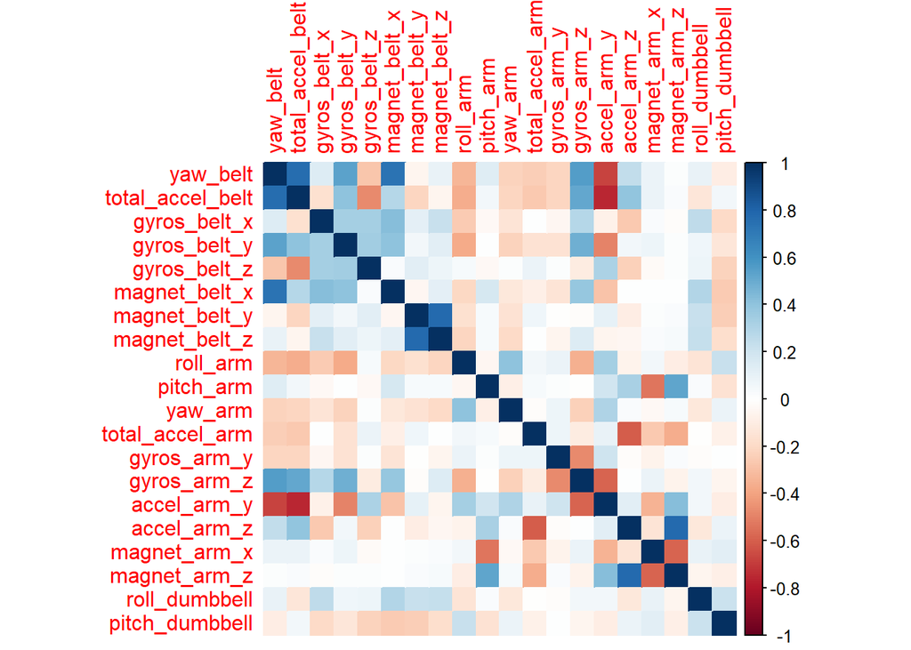

```r
## Loading required package corrplot

corrPlot <- cor(x[1:20])
corrplot(corrPlot, method = 'color')
```

We may take only 20 important features for prediction

```r
library(gbm)
varImp(gbm_model)
```

```
## gbm variable importance
##
##   only 20 most important variables shown (out of 39)
##
##                   Overall
## yaw_belt          100.000
## pitch_forearm      76.160
## magnet_dumbbell_z  67.257
## magnet_belt_y      49.288
## gyros_belt_z       44.039
## magnet_belt_z      43.307
## roll_forearm       42.198
## magnet_dumbbell_y  39.065
## accel_dumbbell_y   22.787
## accel_forearm_z    21.425
## roll_dumbbell      21.274
## accel_forearm_x    20.194
## magnet_forearm_z   19.219
## gyros_dumbbell_y   17.791
## total_accel_belt   17.266
## yaw_arm            15.561
## magnet_dumbbell_x  15.489
## roll_arm           14.303
## magnet_arm_z       12.783
## gyros_arm_y         9.679
```

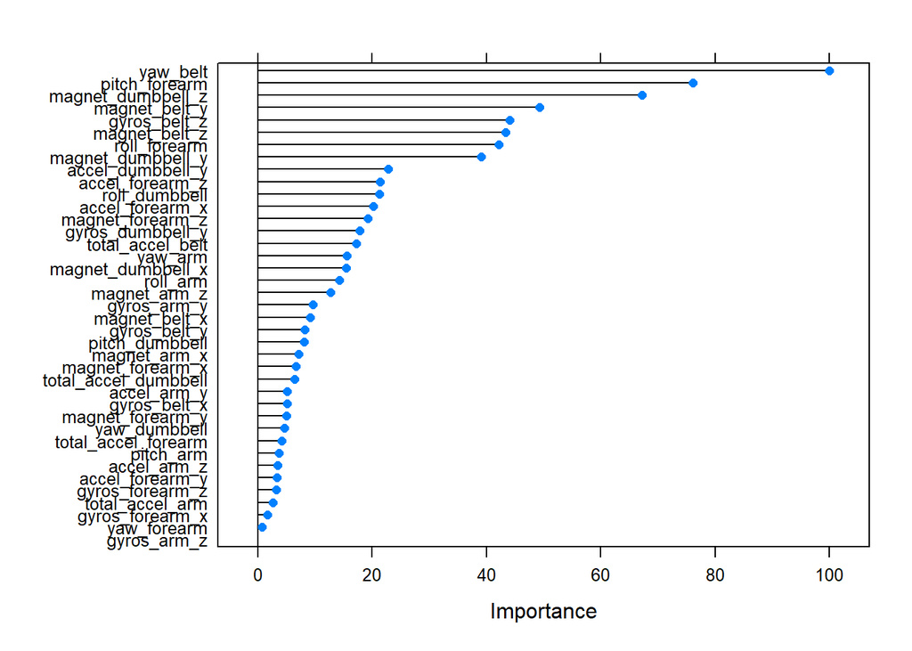

```r
plot(varImp(gbm_model))
```

Plotting the models:

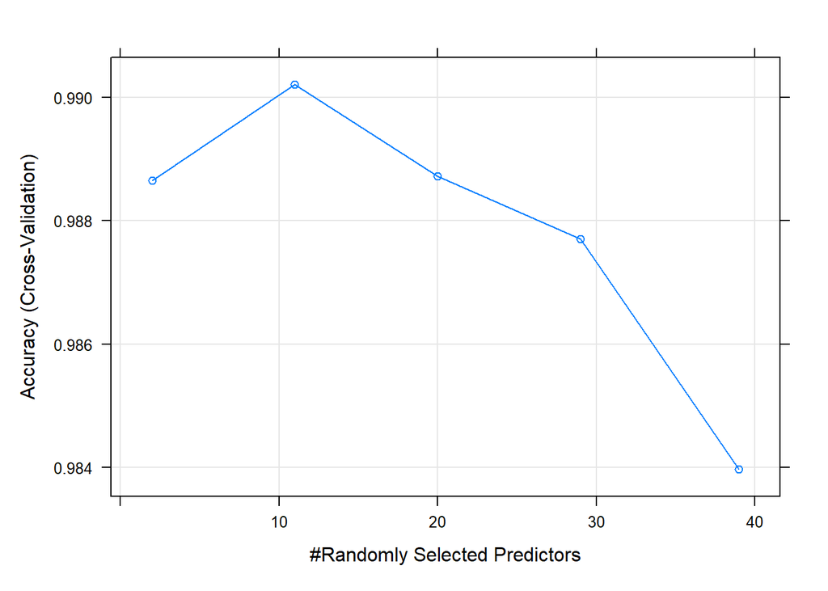

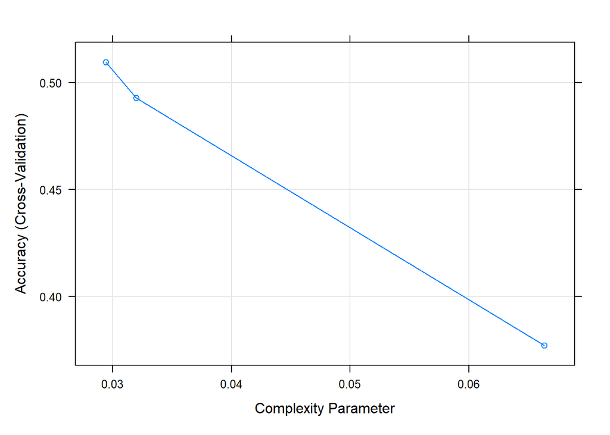

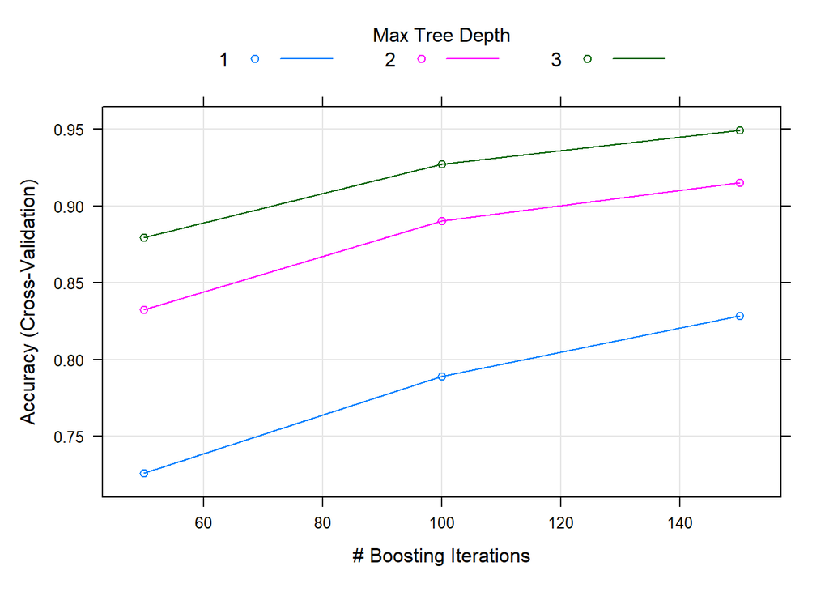

Ugulino, Wallace, Débora Cardador, Katia Vega, Eduardo Velloso, Ruy Milidiú, and Hugo Fuks. 2012. “Wearable Computing: Accelerometers’ Data Classification of Body Postures and Movements.” In, 52–61. Springer Berlin Heidelberg. https://doi.org/10.1007/978-3-642-34459-6_6.